# Exoplanets

Valeriu Tocitu

August 22, 2016

[output not shown]

# Univariate Plots

## What is the structure of your dataset?

NAME: The name of the planet

Mass (mjupiter): This represents the mass of the planet as a ratio of Jupiter’s mass. Due to the early bias of early methods towards Gas Giants, planet mass and radius are given as a ratio of Jupiter’s. Due to the large size of Jupiter relative to ALL other planets in the solar system, a logarithmic scale must be used so as not to exclude smaller planets

Radius R (rjupiter): This represents the radius of the planet as a ratio of Jupiter’s radius.

Gravity: The gravity on the planet’s surface. This is an arbitrary value for Gas Giants,

Period (days): This is how long a “year” is on one of those planets. Very early planets tended to orbit closely to their star, which increased the oscillations favored by the Gravity Method

Rstar (rsun): The smaller the star, the smaller the planet that could be detected.

#### Planet Discovery Methods

PLANETDISCMETHOD: Method used to discover the planet. This is a category, since there are very few methods used. The methods are as follows

Transit: The planet moving in front of its star causes an eclipse when viewed from Earth and thus the star’s luminosity decreases.

Transit Timing Variation: Once a planet has been discovered by the transit method, a decrease in brightness is to be expected at a period of a planet’s orbit. If a repeated decrease in brightness occurs outside of that period, it may indicate the presence of a second planet.

Timing: Other timing methods such as Pulsar Timing (for planets discovered around Pulsars)

Microlensing: The planet’s gravity bends the star’s light, causing a doppler shift in the starlight.

Radial Velocity (RV): The planet’s gravity causes the star to oscillate. By measuring the oscillation, we can approximate the planet’s mass, radius, and orbit. This was the earliest method used, and it typically favors larger planets.

Imaging: The planet was directly imaged. This is a new method at the time the data was collected.

#### Orbital Elements

The remaining variables are the object’s orbital mechanics. Orbits are measured in ellipses around the Sun. We don’t care about their actual coordinates, just the shape of the orbit. They are:

Semi-major axis (A): This is defined as the longest diameter of the orbit. This is the farthest distance between the planet and the star, measured in Astronomical Units

Eccentricity (e): This measures how elongated an ellipse is. It has a range of 0 –> 1, where 0 is a perfect circle.

## Plot the count of planet Periods

```
## [1] 5428   10
```

```
##  [1] "NAME"           "A"              "Period"         "Eccentricity"
##  [5] "OM"             "PLANETDISCMETH" "Mass"           "Gravity"
##  [9] "R"              "Rstar"
```

```
##      NAME                 A                 Period
##  Length:5428        Min.   :  0.00585   Min.   :     0.3
##  Class :character   1st Qu.:  0.05502   1st Qu.:     4.9
##  Mode  :character   Median :  0.10550   Median :    13.1
##                     Mean   :  0.35333   Mean   :   247.3
##                     3rd Qu.:  0.24604   3rd Qu.:    46.3
##                     Max.   :113.44300   Max.   :318498.0
##                     NA's   :84          NA's   :12
##   Eccentricity          OM         PLANETDISCMETH          Mass
##  Min.   :0.0000   Min.   :-103.0   Length:5428        Min.   : 0.00000
##  1st Qu.:0.0000   1st Qu.:  90.0   Class :character   1st Qu.: 0.01042
##  Median :0.0000   Median :  90.0   Mode  :character   Median : 0.01789
##  Mean   :0.0272   Mean   : 122.6                      Mean   : 0.44366
##  3rd Qu.:0.0000   3rd Qu.: 113.0                      3rd Qu.: 0.12574
##  Max.   :0.9700   Max.   : 359.4                      Max.   :22.62610
##  NA's   :857      NA's   :3935                        NA's   :73
##     Gravity            R                Rstar
##  Min.   :0.000   Min.   :   0.027   Min.   :  0.100
##  1st Qu.:0.000   1st Qu.:   0.121   1st Qu.:  0.815
##  Median :0.000   Median :   0.190   Median :  0.970
##  Mean   :1.579   Mean   :   7.067   Mean   :  1.405
##  3rd Qu.:3.203   3rd Qu.:   0.326   3rd Qu.:  1.200
##  Max.   :4.730   Max.   :4332.124   Max.   :149.058
##  NA's   :4910    NA's   :567        NA's   :129
```

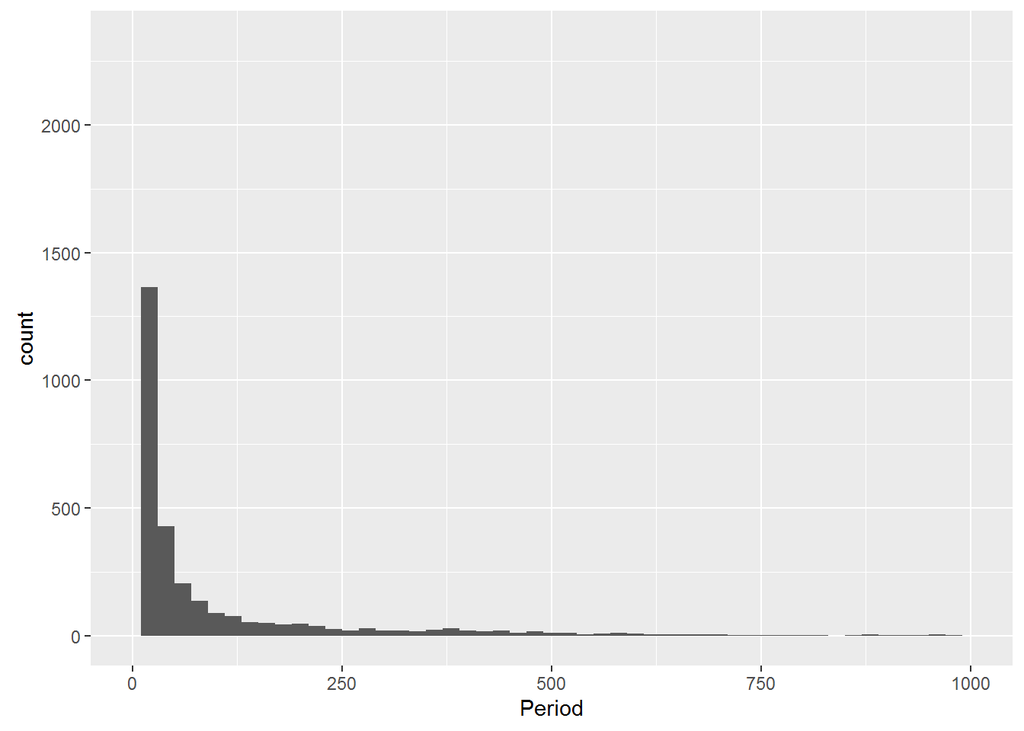

```
##     Min.  1st Qu.   Median     Mean  3rd Qu.     Max.     NA's
##      0.3      4.9     13.1    247.3     46.2 318500.0       12
```

[output not shown]

Most of the planets have a median period of 13.1 days. There are a few outliers which drag the mean out. In addition, 12 do not have a period listed. This is either because we don’t know the period, or they are free-floating planets with no orbit

## Plot the number of planet masses as a ratio of Jupiter’s

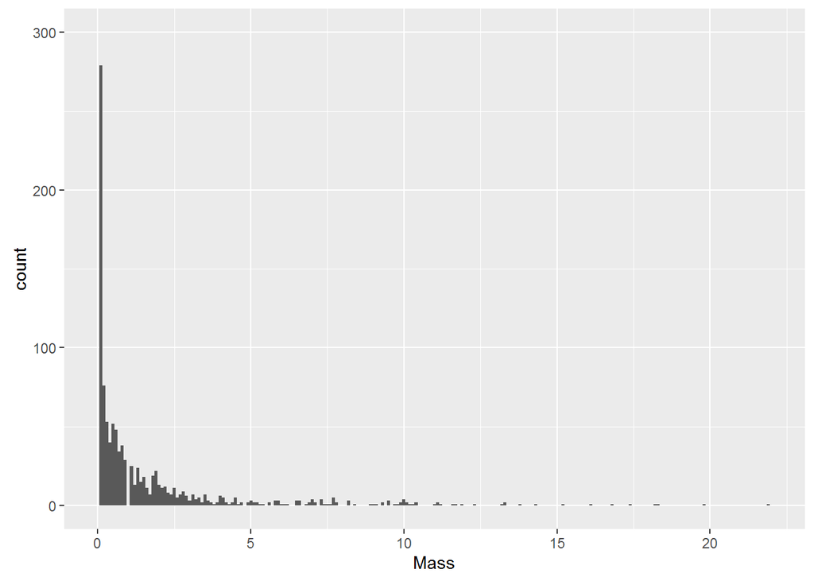

```
##     Min.  1st Qu.   Median     Mean  3rd Qu.     Max.     NA's
##  0.00000  0.01042  0.01789  0.44370  0.12570 22.63000       73
```

Most of the planets have a mass that is about 0.02 times that of Jupiter. Hoever, you have an outlier of 23 times that of Jupiter. There is not enough information to tell whether this lower mass indicates more rocky as opposed to gas worlds.

## Plot the count of various eccentricities

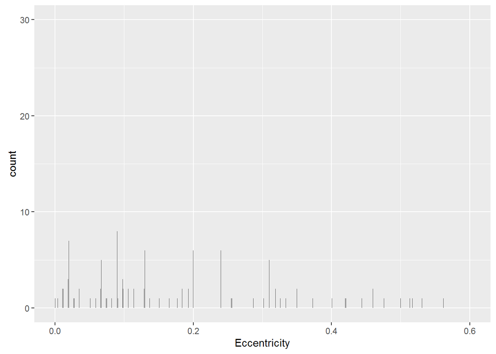

```
##    Min. 1st Qu.  Median    Mean 3rd Qu.    Max.    NA's
##  0.0000  0.0000  0.0000  0.0272  0.0000  0.9700     857
```

As expected from the short period most planets have, eccentricity is very low. There is one planet who’s very close to the eccentricity of 1 which indicates that it is being kicked out of the star system.

## Plot the count of the planet’s radius as a ratio of the Jupiter’s

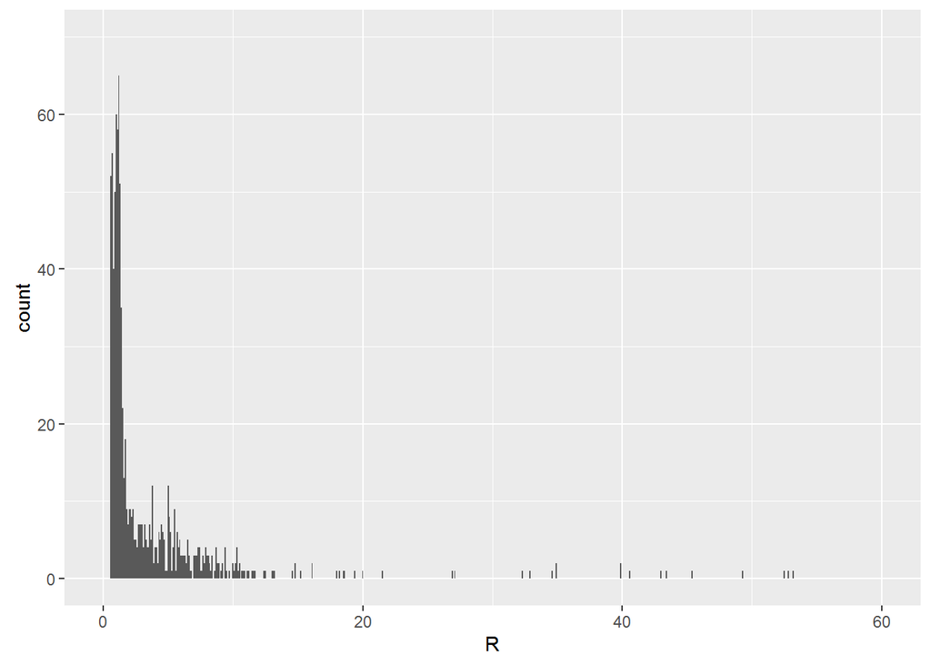

```
##     Min.  1st Qu.   Median     Mean  3rd Qu.     Max.     NA's
##    0.027    0.121    0.190    7.067    0.326 4332.000      567
```

According to Wikipedia, the ratio between earth and Jupiter is about 0.09. This hints that the planets discovered have a median radius about twice that of Earth. There are outliers, as can be seen by the maximum value.

## Plot the frequency of semi-major axis

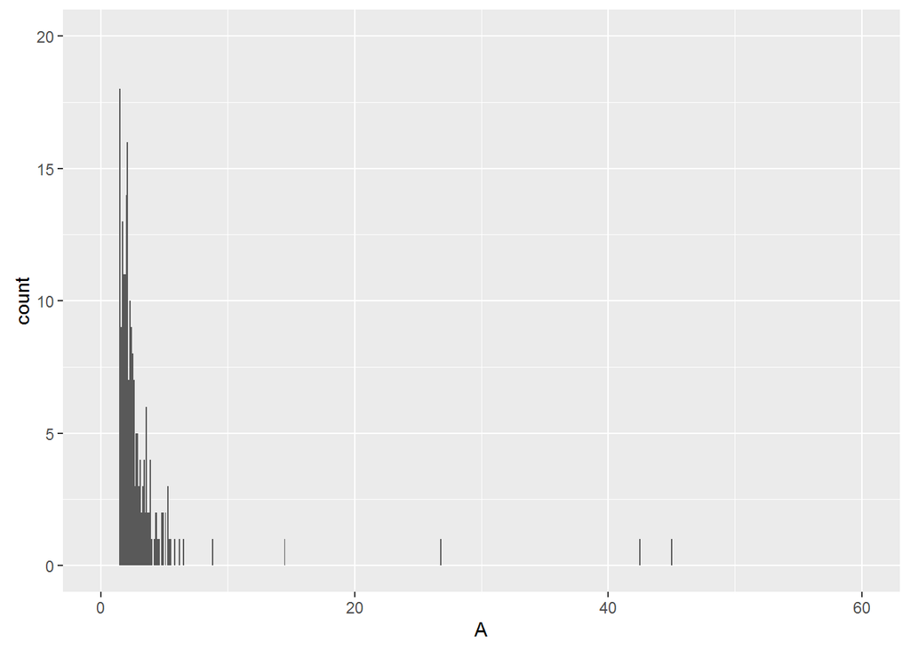

```
##      Min.   1st Qu.    Median      Mean   3rd Qu.      Max.      NA's
##   0.00585   0.05502   0.10550   0.35330   0.24600 113.40000        84
```

Earth is 1 au from the Sun. This reinforces the hints given by the Period count. Namely, that most planets listed exist very close to their star.

## Plot the frequency of OM

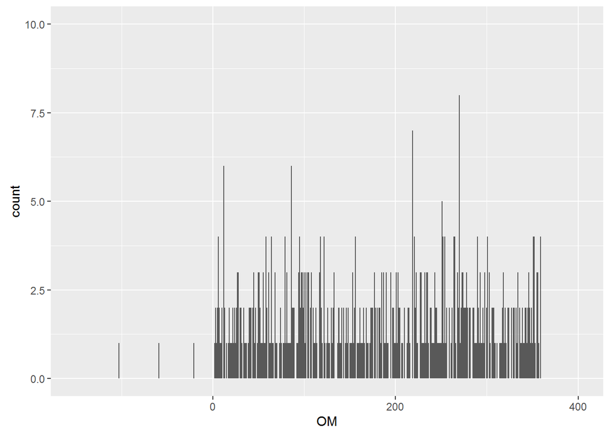

```
##    Min. 1st Qu.  Median    Mean 3rd Qu.    Max.    NA's
##  -103.0    90.0    90.0   122.6   113.0   359.4    3935
```

To best catch an eclipse, the planet needs to have an OM of +/- 90 degrees.

## Plot the frequency of planetary gravity

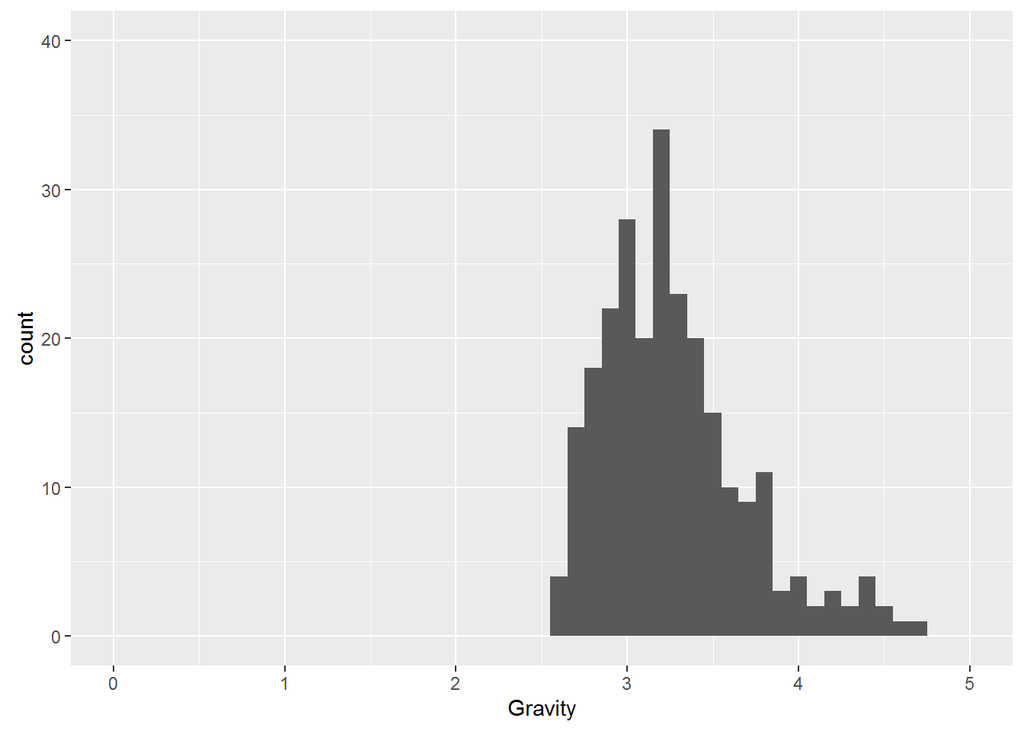

```
##    Min. 1st Qu.  Median    Mean 3rd Qu.    Max.    NA's
##   0.000   0.000   0.000   1.579   3.203   4.730    4910
```

## Plot the count of the star’s radii as a ratio of the Sun’s

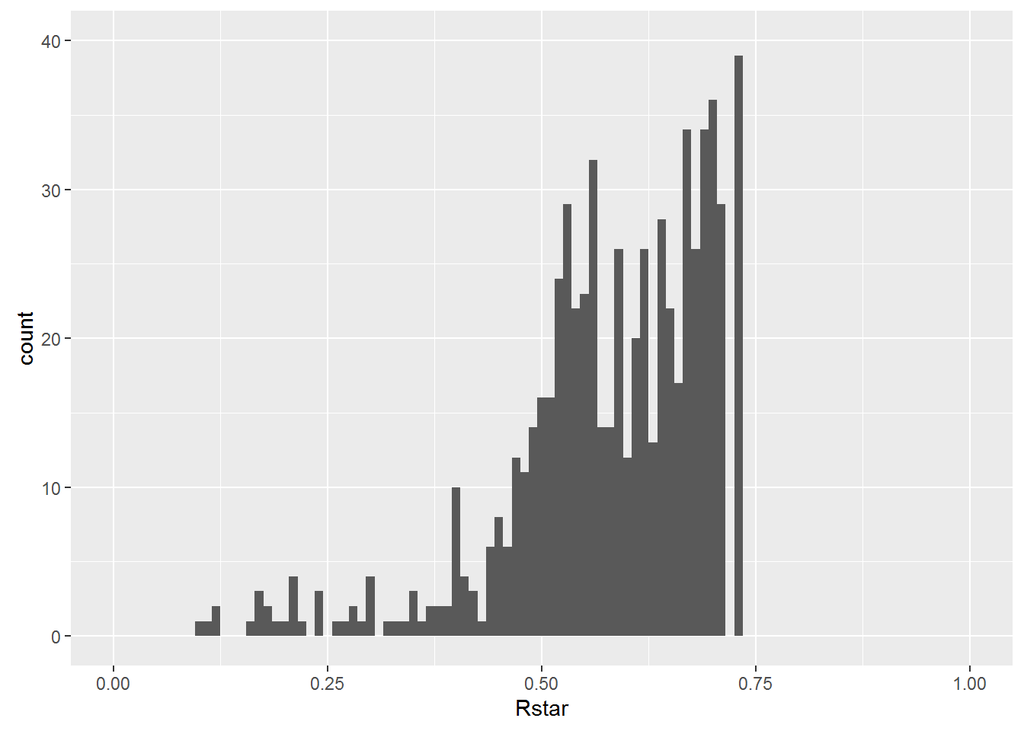

```
##    Min. 1st Qu.  Median    Mean 3rd Qu.    Max.    NA's
##   0.100   0.815   0.970   1.405   1.200 149.100     129
```

# Univariate Analysis

## What data are you interested in

I am interested in the discovery method. I want to see which types of exoplanets are favored by which method of detection

## What other features in the dataset do you think will help support your investigation into your feature(s) of interest?

The planet’s orbital inclination and the distance of the star from Earth.

## Did you create any new variables from existing variables in the dataset?

Yes. I calculated the planetary density can be calculated by a ratio of the planet’s mass and radius. However, I am not familiar enough with the material to use this to distinguish a gas giant from a rocky world.

# Bivariate Plot

### Planet’s radius vs. the star’s radius

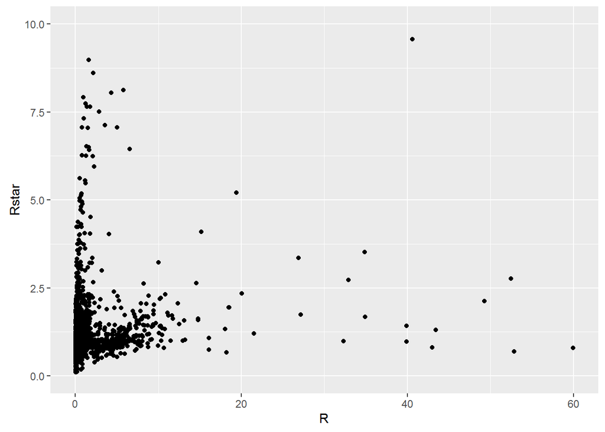

```
##
##  Pearson's product-moment correlation
##
## data:  R and Rstar
## t = 10.494, df = 4814, p-value < 2.2e-16
## alternative hypothesis: true correlation is not equal to 0
## 95 percent confidence interval:
##  0.1218141 0.1770396
## sample estimates:
##       cor
## 0.1495435
```

This data hints that stars with a smaller radius tend to have smaller planets. Another way of looking at this data would be that we can’t detect smaller planets around larger stars, regardless of method used.

### Planet’s mass vs. the star’s radius

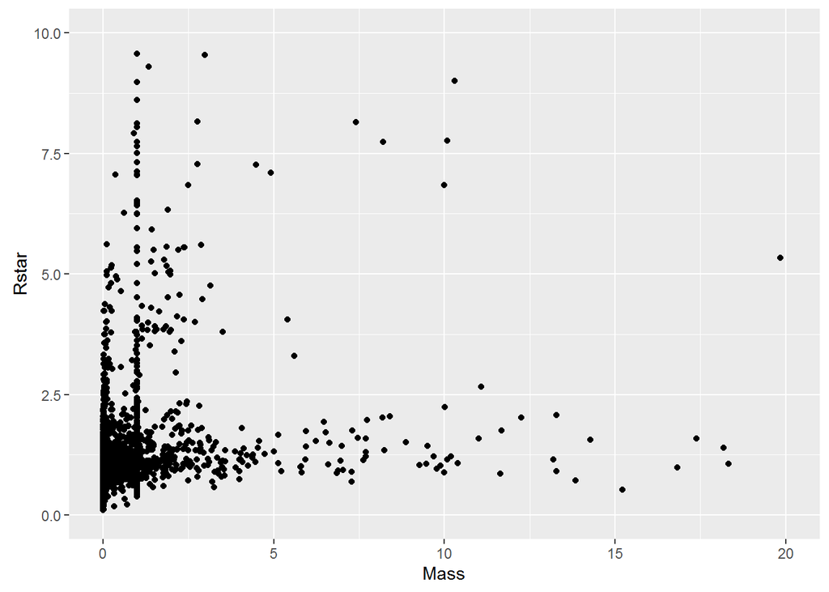

```
##     Min.  1st Qu.   Median     Mean  3rd Qu.     Max.     NA's
##  0.00000  0.01042  0.01789  0.44370  0.12570 22.63000       73
```

```
##    Min. 1st Qu.  Median    Mean 3rd Qu.    Max.    NA's
##   0.100   0.815   0.970   1.405   1.200 149.100     129
```

```
##
##  Pearson's product-moment correlation
##
## data:  Mass and Rstar
## t = 18.639, df = 5230, p-value < 2.2e-16
## alternative hypothesis: true correlation is not equal to 0
## 95 percent confidence interval:
##  0.2239981 0.2748199
## sample estimates:
##       cor
## 0.2495809
```

It is no coincidence that this scatterplot looks very similar to the comparision between the radius of the star and the radius of the planet. After all, planets with smaller radii tend to have less mass, once corrected for density.

### Period vs. the star’s radius

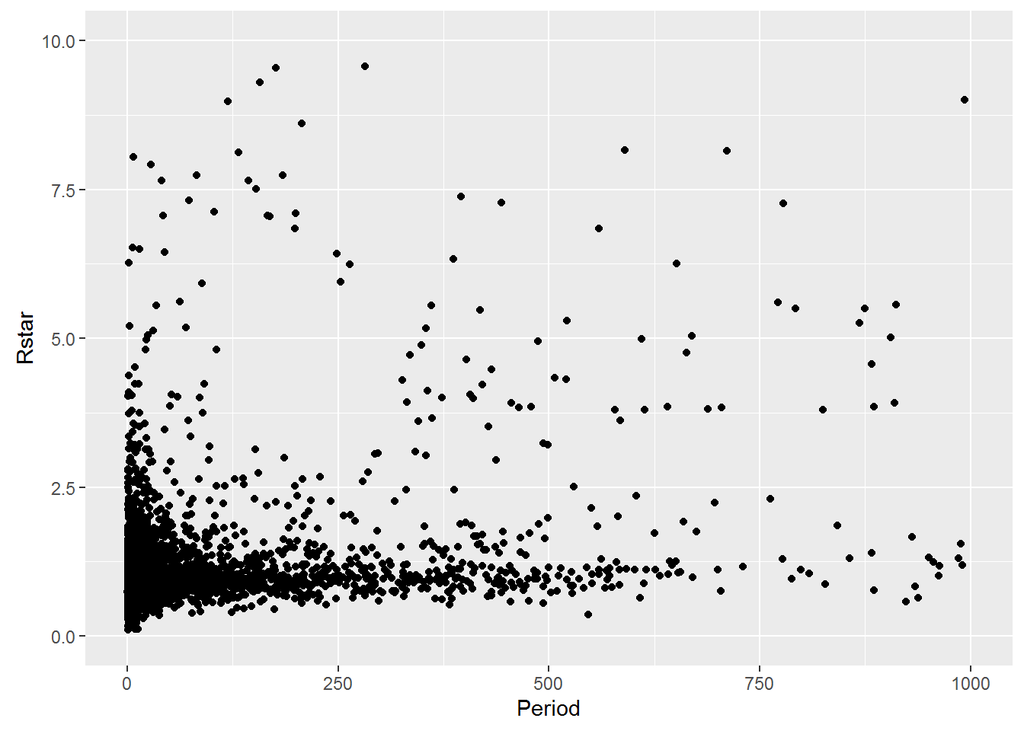

```
##     Min.  1st Qu.   Median     Mean  3rd Qu.     Max.     NA's
##      0.3      4.9     13.1    247.3     46.2 318500.0       12
```

```
##    Min. 1st Qu.  Median    Mean 3rd Qu.    Max.    NA's
##   0.100   0.815   0.970   1.405   1.200 149.100     129
```

```
##
##  Pearson's product-moment correlation
##
## data:  Period and Rstar
## t = -0.71729, df = 4067, p-value = 0.4732
## alternative hypothesis: true correlation is not equal to 0
## 95 percent confidence interval:
##  -0.04195992  0.01948737
## sample estimates:
##         cor
## -0.01124689
```

This scatter plot shows a very weak correlation between the period and the star’s radius. This might be due to the fact that most planets documented have been found around stars within a narrow Range of radii. I am not aware whether this is due to a relative lack of stars with larger radii in the explored region of the galaxy, a relative lack of planets around those stars, or simply that the planet discovery methods don’t work as well around those stars.

### Planet’s eccentricity vs semi-major axis

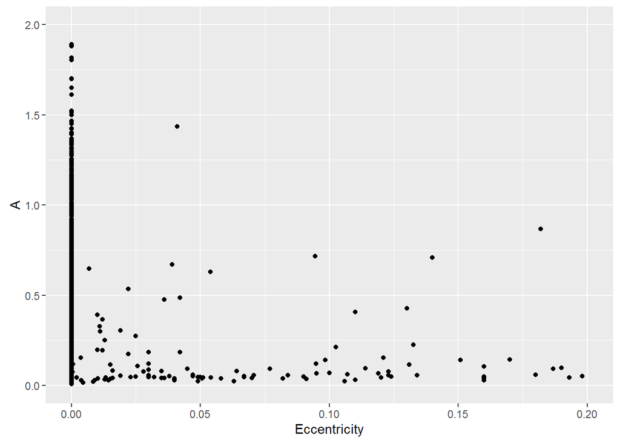

```
##    Min. 1st Qu.  Median    Mean 3rd Qu.    Max.    NA's
##  0.0000  0.0000  0.0000  0.0272  0.0000  0.9700     857
```

```
##      Min.   1st Qu.    Median      Mean   3rd Qu.      Max.      NA's
##   0.00585   0.05502   0.10550   0.35330   0.24600 113.40000        84
```

```
##
##  Pearson's product-moment correlation
##
## data:  Eccentricity and A
## t = 35.457, df = 4563, p-value < 2.2e-16
## alternative hypothesis: true correlation is not equal to 0
## 95 percent confidence interval:
##  0.4417142 0.4872096
## sample estimates:
##       cor
## 0.4647686
```

### Method of Discovery vs star’s radius

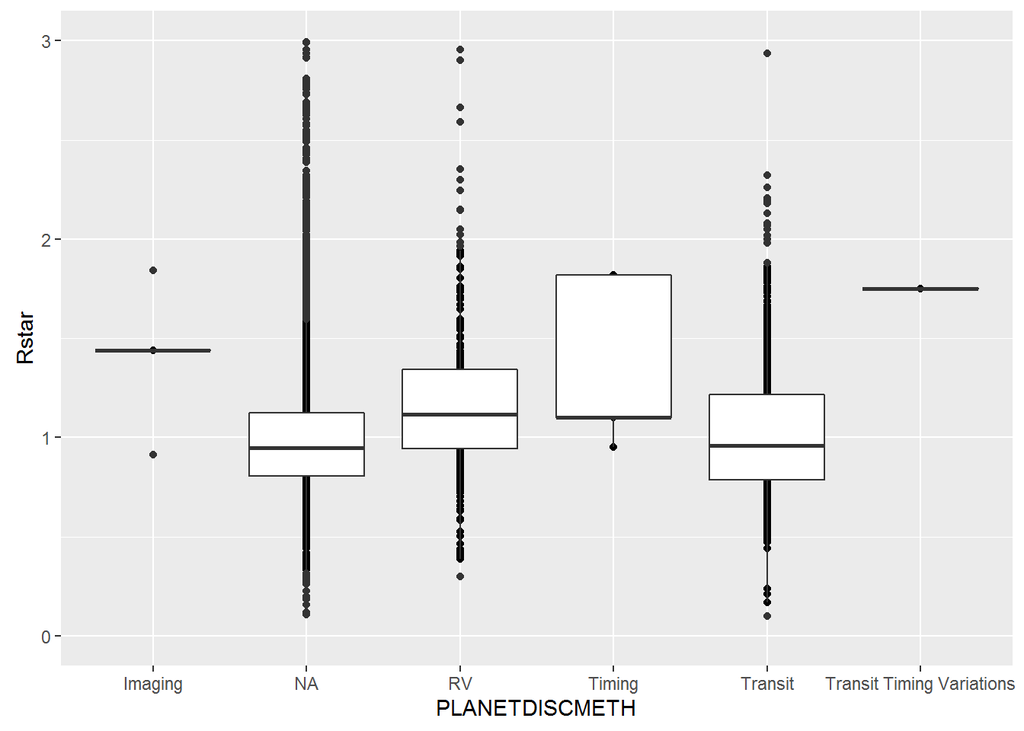

### Method of Discovery vs planet’s radius

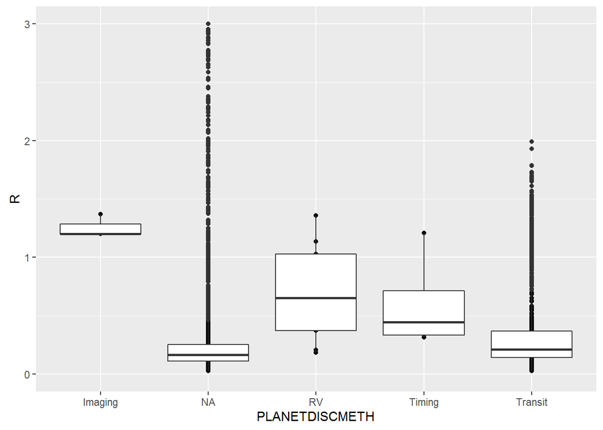

### Method of Discovery vs planet’s mass

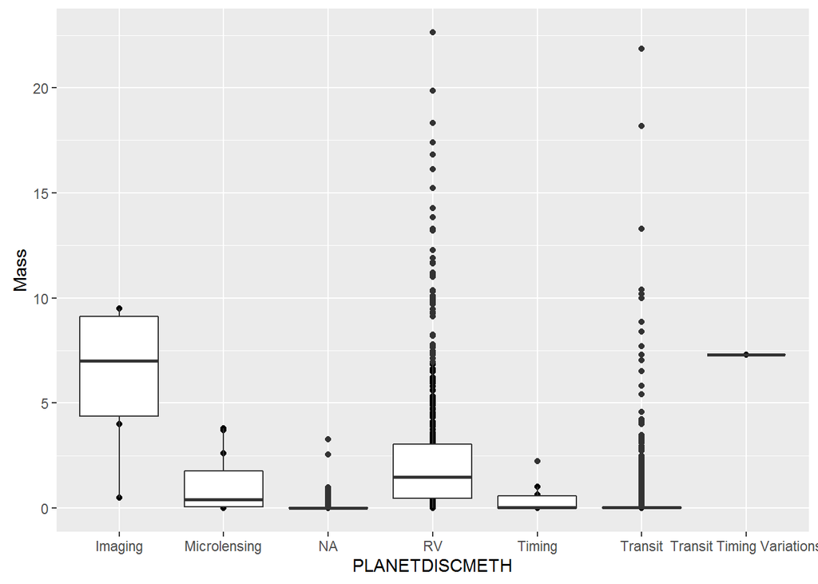

Since the masses of the planets discovered doesn’t have nearly as wide a range, there was no need to exclude planets except those whose mass is not known.Since the density of planets varies, it is not advisable to take the mass alone into consideration in exploring biases to the discovery methods. Thus, density is best employed here.

# Bivariate Analysis

## Talk about some of the relationships you observed in this part of the investigation. How did the feature(s) of interest vary with other features in the dataset?

It is difficult to establish correlations between the radius of the star and any orbital or physical properties of the planets in question. Correlations do exist, but they are very weak. Again, it is not possible to determine from this limited data whether this is due to the fact that planets are likely to form around stars with smaller radii, or due to scientist’s desire to find an Earth-like planet around a Sun-like star.

```
##    Length     Class      Mode
##      5428 character character
```

Most planets do not list the method with which they were discovered. Those that do predominantly were discovered via Radial Velocity. Radial Velocity was the first method used to detect planets, and was for a time the only method used. Most planets to date have been discovered by the Kepler Space Telescope, which uses Microlensing to detect planets.

The facts above mean that RV was used to discover the widest diversity of planets. However, this is not enough to say that either represents the median of all the planets in the galaxy. Despite its 20 plus year existence, the field of planetary detection is still in its infancy.

## Did you observe any interesting relationships between the other features (not the main feature(s) of interest)?

There is no statistically significant relationship between the planet’s period and the star’s radius.

## What was the strongest relationship you found?

The strongest relationship was between Eccentricity and semi-major axis.

# Multivariate Plot

### Method of Discovery vs. planet’s density

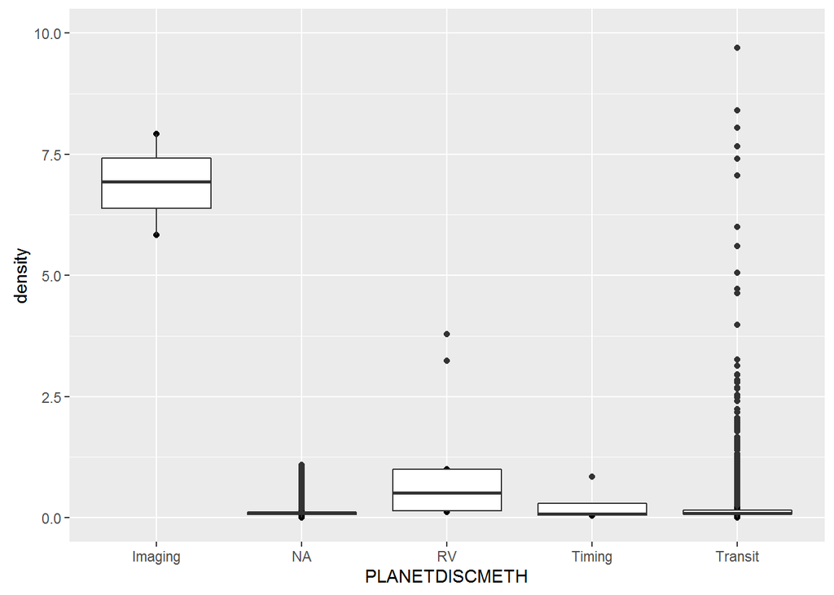

Most methods were used to detect planets with very low densities. Surprisingly, Imaging and Radial Velocity (RV) have higher desnities. There is not enough information in the data to determine why this phenomenon exists, since it seems to go against the assumption that those methods work better for gas giants.

### Planet’s radius vs. the star’s radius with method of discovery

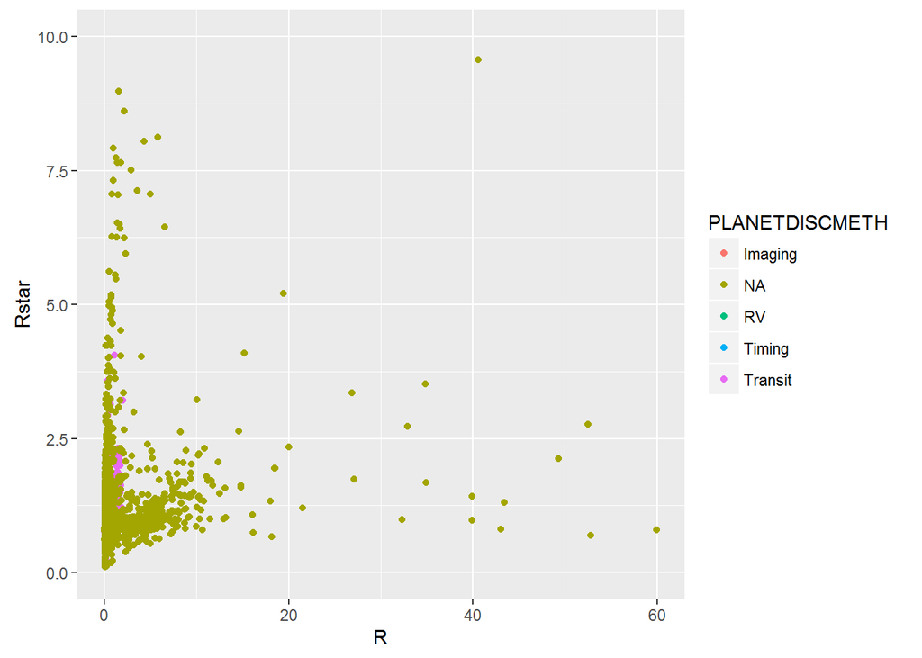

### Planet’s mass vs. the star’s radius with method of discovery

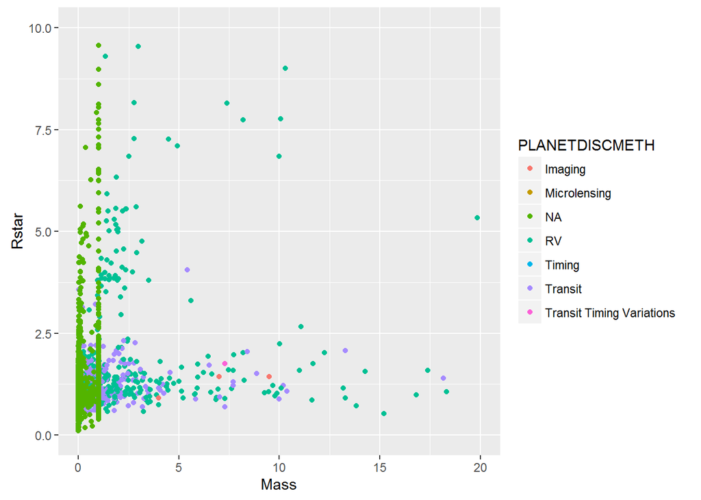

From this, we can conclude that the method of discovery for more massive planets is known, but this relationship isn’t shown between the star’s radius and the method of discovery.

### Period vs. the star’s radius with method of discovery

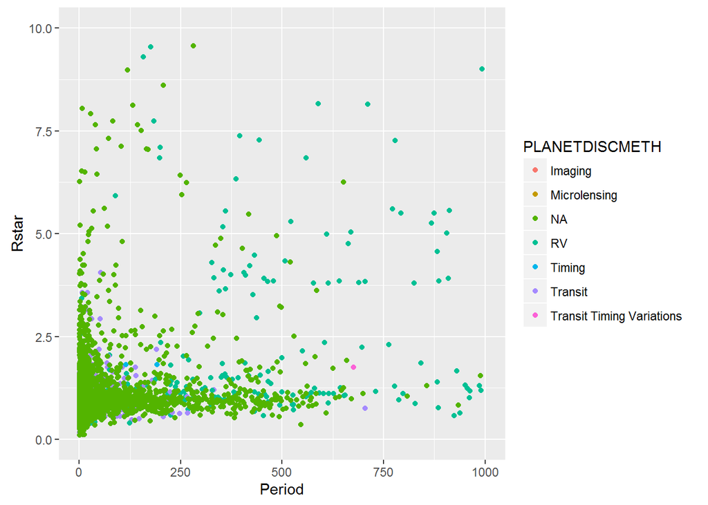

The planets with unknown discovery methods are more spread out in terms of both the distribution of Period and Rstar. This hints at the possibility that no discovery method listed favors a specific planetary period.

### Planet’s eccentricity vs semi-major axis with method of discovery

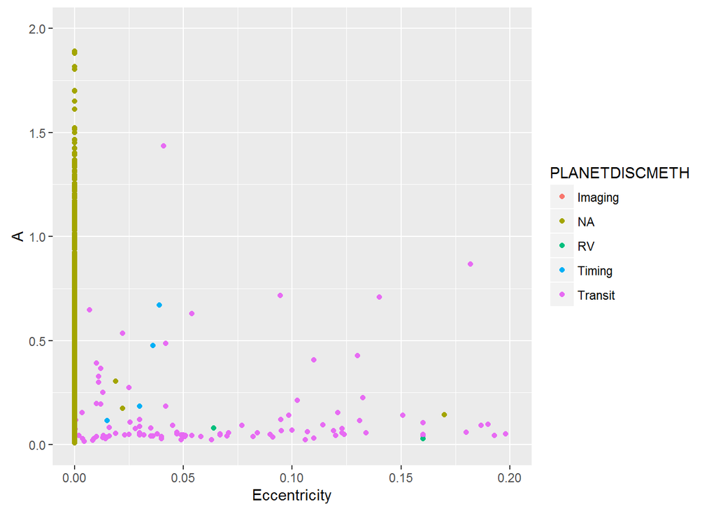

This plot argues that Transit and Timing discovery methods were used to discover planets with known orbital mechanics characteristics. In a way, it is not surprising, since those methods require the knowledge of the planet’s orbital variables.

# Multivariate Analysis

## Talk about some of the relationships you observed in this part of the investigation. Were there features that strengthened each other in terms of looking at your feature(s) of interest?

Some of the analysis for from the Bivariate Plots was redone using density. A planet’s radius is far more telling of its composition than its mass, but density is best to get a glimpse of the relationships that gas giants have with the other parameters. A reminder that the density threshold between a gas giant and a rocky world is not known as part fo this data. Thus, no attempt is made to classify the worlds.

## Were there any interesting or surprising interactions between features?

# Final Plots and Summary

When it comes to comparing the method of discovery to planetary characteristics, we’ve found the stronger relationship to be between the planetary radius and method of discovery. The following plots summarize this relationship.

## Frequency of Planet’s Radius

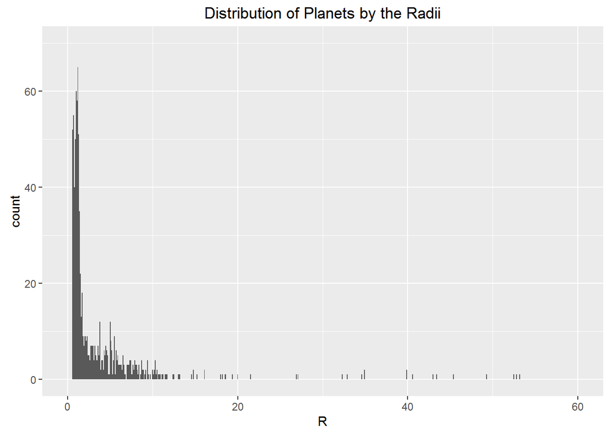

This plot gives the strongest hint that most of the planets discovered have a smaller radius than twice that of Jupiter. This means that we can treat bigger planets almost as an outlier.

### Method of Discovery vs planet’s radius

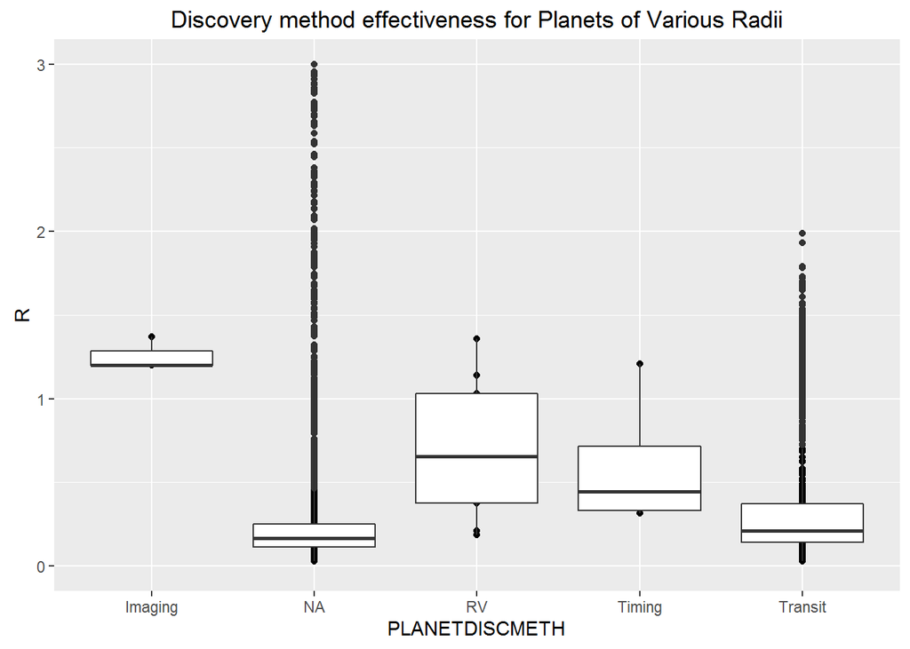

When it comes to comparing the method of discovery to orbital mechanics, we’ve found the stronger relationship to be between semi-major axis and method of discovery. The following plots summarize this relationship.

## Frequency of semi-major axis

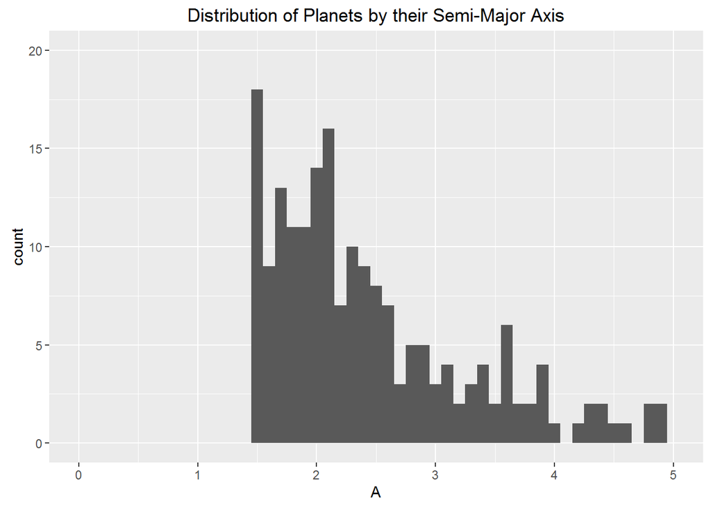

```
##      Min.   1st Qu.    Median      Mean   3rd Qu.      Max.      NA's
##   0.00585   0.05502   0.10550   0.35330   0.24600 113.40000        84
```

### Planet’s eccentricity vs semi-major axis

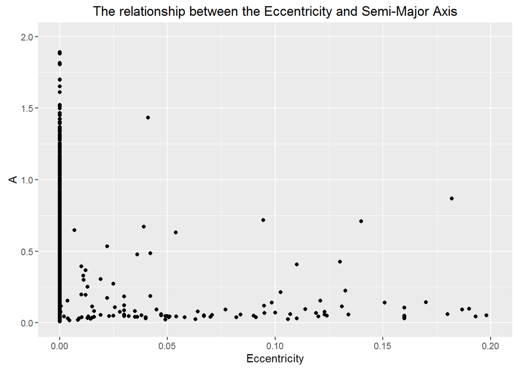

### Planet’s eccentricity vs semi-major axis with method of discovery

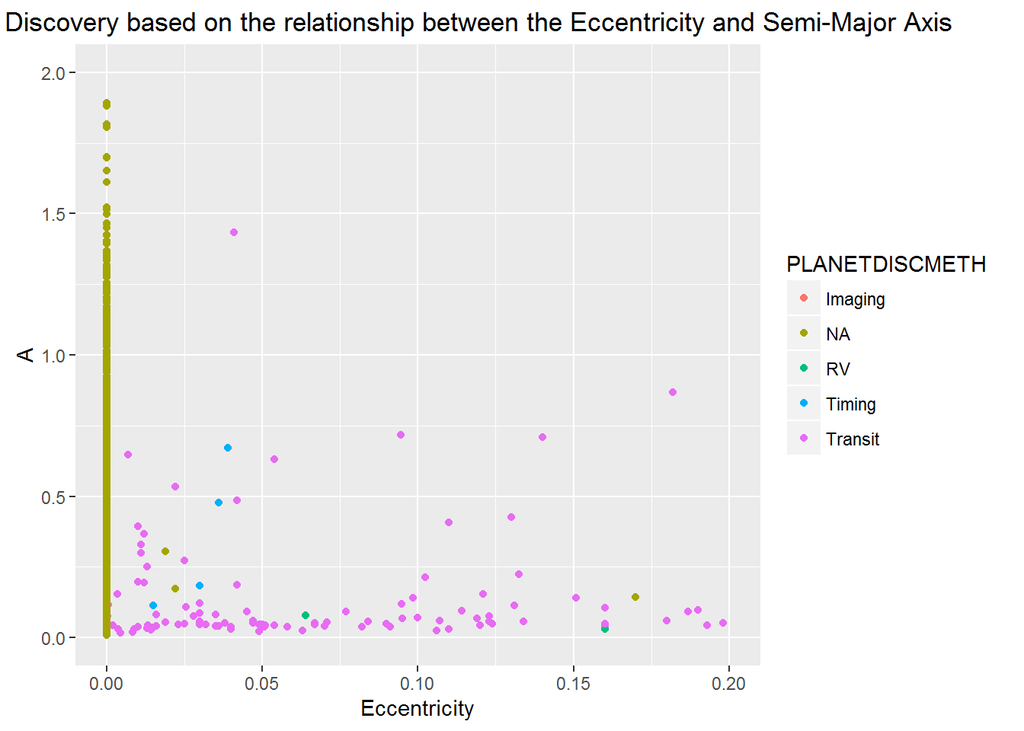

This plot argues that Transit and Timing discovery methods were used to discover planets with known orbital mechanics characteristics. In a way, it is not surprising, since those methods require the knowledge of the planet’s orbital variables.

# Reflection